# Practical Machine Learning

# Models

## Prediction Tree Model

First, the prediction with tree method is used, which iteratively split variable groups,and analyses each group’s homogeneity.

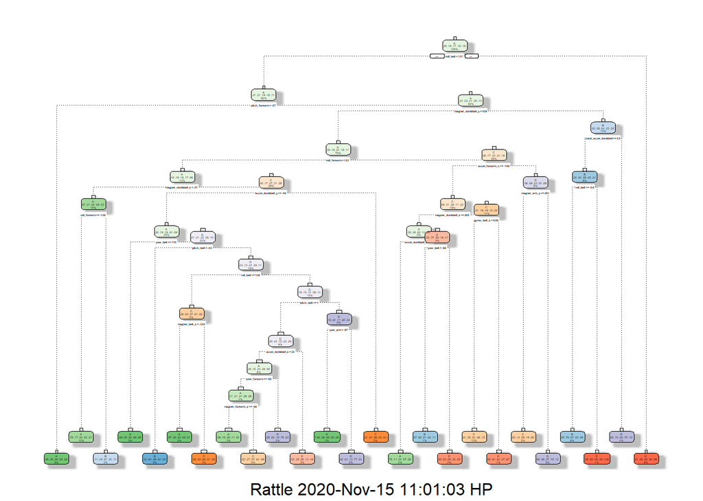

```r
set.seed(1234)
treemod = rpart(classe~.,data=trainData,method="class")
fancyRpartPlot(treemod)
```

```r
treepred = predict(treemod, testData, type="class")
treeconfmat = confusionMatrix(treepred,as.factor(testData$classe))
treeconfmat
```

```
## Confusion Matrix and Statistics
##
##           Reference
## Prediction    A    B    C    D    E
##          A 1552  174   18   60    6
##          B   48  588   43   63   64
##          C   39  220  888  100  148
##          D   24   83   75  651   86
##          E   11   74    2   90  778
##
## Overall Statistics
##
##                Accuracy : 0.7573
##                  95% CI : (0.7462, 0.7683)
##     No Information Rate : 0.2845
##     P-Value [Acc > NIR] : < 2.2e-16
##
##                   Kappa : 0.6926
##
##  Mcnemar's Test P-Value : < 2.2e-16
##
## Statistics by Class:
##
##                      Class: A Class: B Class: C Class: D Class: E
## Sensitivity            0.9271  0.51624   0.8655   0.6753   0.7190
## Specificity            0.9387  0.95407   0.8957   0.9455   0.9631
## Pos Pred Value         0.8575  0.72953   0.6366   0.7084   0.8147
## Neg Pred Value         0.9701  0.89151   0.9693   0.9370   0.9383
## Prevalence             0.2845  0.19354   0.1743   0.1638   0.1839
## Detection Rate         0.2637  0.09992   0.1509   0.1106   0.1322
## Detection Prevalence   0.3076  0.13696   0.2370   0.1562   0.1623
## Balanced Accuracy      0.9329  0.73515   0.8806   0.8104   0.8411
```

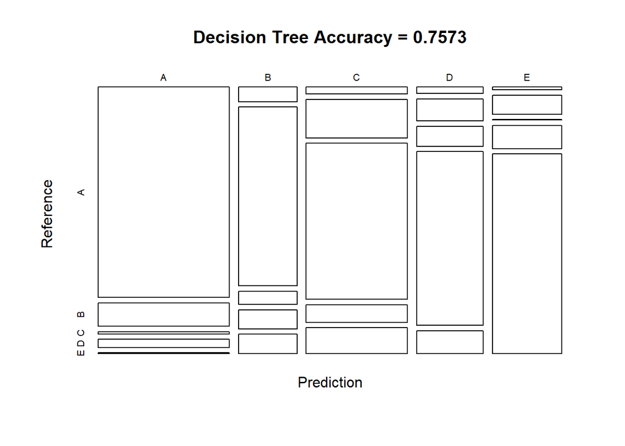

```r
plot(treeconfmat$table,col=treeconfmat$byClass,main=paste("Decision Tree Accuracy =", round(treeconfmat$overall["Accuracy"],4)))
```

## Random Forest Model

This method takes a resample of the observed data from the training data set and builds a regression tree on it, then the new outcome of the classification tree is resampled and reclassified.

```r
trcontrol = trainControl(method = "cv",number = 3,verboseIter = F)
rfmod = train(classe~.,data=trainData,method="rf",trControl=trcontrol)
rfpred = predict(rfmod,testData)
RFconfmat = confusionMatrix(rfpred,as.factor(testData$classe))
RFconfmat
```

```
## Confusion Matrix and Statistics
##
##           Reference
## Prediction    A    B    C    D    E
##          A 1671    6    0    0    0
##          B    2 1124    5    0    0
##          C    0    9 1019   10    4
##          D    0    0    2  954    5
##          E    1    0    0    0 1073
##
## Overall Statistics
##
##                Accuracy : 0.9925
##                  95% CI : (0.99, 0.9946)
##     No Information Rate : 0.2845
##     P-Value [Acc > NIR] : < 2.2e-16
##
##                   Kappa : 0.9905
##
##  Mcnemar's Test P-Value : NA
##
## Statistics by Class:
##
##                      Class: A Class: B Class: C Class: D Class: E
## Sensitivity            0.9982   0.9868   0.9932   0.9896   0.9917
## Specificity            0.9986   0.9985   0.9953   0.9986   0.9998
## Pos Pred Value         0.9964   0.9938   0.9779   0.9927   0.9991
## Neg Pred Value         0.9993   0.9968   0.9986   0.9980   0.9981
## Prevalence             0.2845   0.1935   0.1743   0.1638   0.1839
## Detection Rate         0.2839   0.1910   0.1732   0.1621   0.1823
## Detection Prevalence   0.2850   0.1922   0.1771   0.1633   0.1825
## Balanced Accuracy      0.9984   0.9927   0.9942   0.9941   0.9957
```

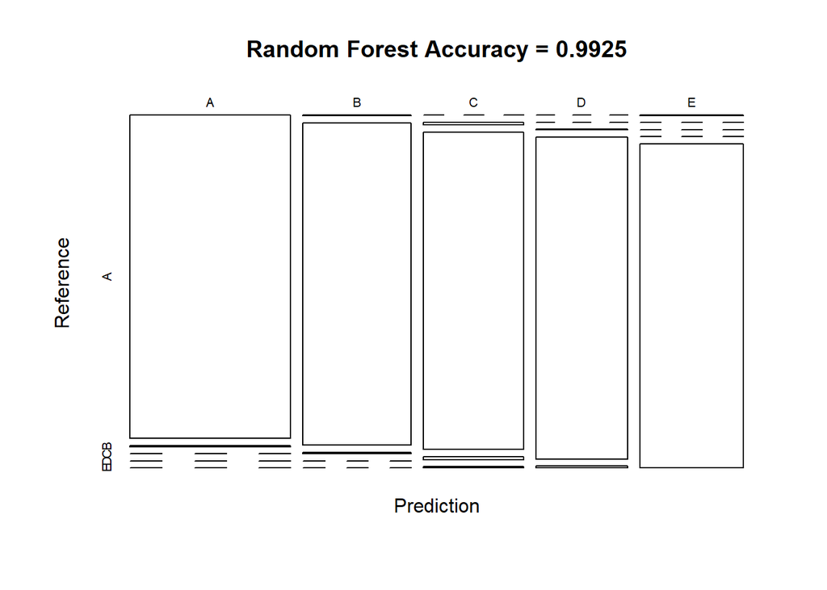

```r
plot(RFconfmat$table,col=RFconfmat$byClass,main=paste("Random Forest Accuracy =",round(RFconfmat$overall["Accuracy"],4)))
```

## Generalized Boosting Model

This method takes a lot of weak predictors and utilizes each predictor’s strength, building them up to become a strong predictor.

```r
trcontrol2 = trainControl(method="repeatedcv",number = 5, repeats = 1)
gbmfit = train(classe~., data=trainData, method="gbm", trControl=trcontrol2,verbose=F)
gbmfit$finalModel
```

```
## A gradient boosted model with multinomial loss function.
## 150 iterations were performed.
## There were 52 predictors of which 52 had non-zero influence.
```

```r
gbmpred = predict(gbmfit, testData)
gbmconfmat = confusionMatrix(gbmpred, as.factor(testData$classe))
gbmconfmat
```

```
## Confusion Matrix and Statistics
##
##           Reference
## Prediction    A    B    C    D    E
##          A 1647   28    0    3    6
##          B   17 1081   27    5    9
##          C    5   28  984   29   21
##          D    4    2   14  919   18
##          E    1    0    1    8 1028
##
## Overall Statistics
##
##                Accuracy : 0.9616
##                  95% CI : (0.9564, 0.9664)
##     No Information Rate : 0.2845
##     P-Value [Acc > NIR] : < 2.2e-16
##
##                   Kappa : 0.9514
##
##  Mcnemar's Test P-Value : 4.129e-07
##
## Statistics by Class:
##
##                      Class: A Class: B Class: C Class: D Class: E
## Sensitivity            0.9839   0.9491   0.9591   0.9533   0.9501
## Specificity            0.9912   0.9878   0.9829   0.9923   0.9979
## Pos Pred Value         0.9780   0.9491   0.9222   0.9603   0.9904
## Neg Pred Value         0.9936   0.9878   0.9913   0.9909   0.9889
## Prevalence             0.2845   0.1935   0.1743   0.1638   0.1839
## Detection Rate         0.2799   0.1837   0.1672   0.1562   0.1747
## Detection Prevalence   0.2862   0.1935   0.1813   0.1626   0.1764
## Balanced Accuracy      0.9875   0.9684   0.9710   0.9728   0.9740
```

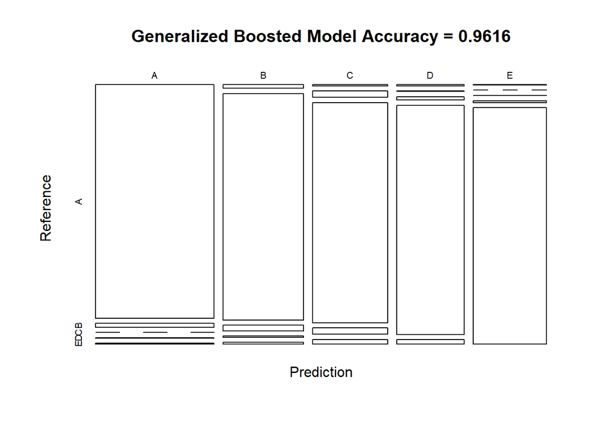

```r
plot(gbmconfmat$table,col=gbmconfmat$byClass,main=paste("Generalized Boosted Model Accuracy =",round(gbmconfmat$overall["Accuracy"],4)))
```

## Validation Data Set Prediction

From the model plots, it is seen that the random forest method has the highest accuracy of prediction. It is then used to predict the outcome of the validation data set.

```r
predict(rfmod, validation)
```

```
##  [1] B A B A A E D B A A B C B A E E A B B B
## Levels: A B C D E
```